# Final Assignment, Task 4

Tue Minh Nguyen

25/10/2024

# Task 4 - Insights

## Task 4 description

The COVID-19 pandemic has had a significant global impact, with multiple waves affecting various regions at different times. The goal is to create a visually engaging and informative dashboard that clearly communicates the trends and key figures related to each wave of COVID-19. This dashboard should provide a comprehensive overview of the pandemic’s progression, helping the public understand its dynamics, learn from the data, and make informed decisions about their health and safety. The main objectives of this project include data augmentation, visualization design, and ensuring public accessibility. The handcrafted dashboard is anticipated to be an effective tool for raising public awareness and educating people about COVID-19 trends. By offering clear visuals and key insights, it will enhance understanding and engagement among the public, empowering them to make informed decisions in response to the ongoing pandemic. Additionally, the dashboard can serve as a template for future public health data visualization initiatives, allowing for adaptation to other health crises as needed.

**Task 4 Report**: To create a comprehensive handcrafted dashboard that illustrates global trends and key figures related to the various COVID-19 waves, it is essential to enhance the initial dataset by incorporating data from subsequent waves. To begin, I will seek additional data sources, such as public health organizations like the World Health Organization (WHO), by accessing their databases and reports. These sources typically provide valuable information on infection rates, recoveries, deaths, and vaccination progress. I will also explore studies published by universities and research institutions that analyze COVID-19 trends and their implications. These studies may reveal insights into demographic impacts, variations in mutations, and regional responses to the pandemic. Additionally, I will review academic journals that focus on epidemiology and public health, looking for reports on the spread of variants, vaccine effectiveness, and changes in social behavior due to COVID-19.

I will utilize several data types for augmentation, including vaccination rates, which encompass coverage for first and second doses, booster doses, and demographic breakdowns of vaccinated populations. Additionally, I will incorporate map-based data to illustrate the geographical spread of COVID-19 waves across different countries and regions. Information on government interventions, such as lockdowns, mask mandates, travel restrictions, and other public health policies enacted during various waves will also be included. Finally, I will analyze surveys and social media sentiment to assess public compliance with health measures and attitudes toward vaccination. By integrating these data types, I aim to create a comprehensive understanding of the pandemic’s impact.

The key insights I want to emphasize for the public include several important aspects. First, I aim to showcase the correlation between vaccination rates and health outcomes. In terms of geographical variations, I will highlight regions that exhibit the highest and lowest infection rates, vaccination coverage, and health outcomes. Regarding government interventions, I will present information on lockdowns and travel restrictions implemented during the pandemic. Lastly, I want to illustrate changes in public compliance with health measures, such as mask mandates and social distancing, over time.

I will utilize bar charts to compare vaccination rates across regions and demographics, highlighting disparities and aiding targeted outreach efforts. These charts will also display the duration of interventions like lockdowns and travel bans during different waves of the pandemic. Additionally, a scatter plot will correlate vaccination rates with infection and death rates, illustrating the impact of vaccination on health outcomes. Overall, effective visualizations simplify complex data, enhance public engagement, and raise awareness about the pandemic while educating the community on the importance of ongoing health measures.

To effectively organize my dashboard layout, I will use contrasting colors to represent different vaccination and infection rates, employing warm colors (such as red and orange) for higher rates and cooler colors (like green and blue) for lower rates. This approach will help viewers quickly identify critical insights. A neutral background will be selected to ensure the data visualizations stand out and remain easy to read. For typography, I will choose clear, legible sans-serif fonts, with larger sizes for headings and slightly smaller sizes for body text. Key insights and headings will be bolded to attract attention, while smaller font sizes will be reserved for supplementary information. Consistent font sizes and styles throughout the dashboard will enhance readability and create a cohesive appearance.

The top section will feature a scatter plot that illustrates the relationship between vaccination rates and health outcomes, accompanied by a brief narrative that provides context for the data presented. In the central area, I will place bar charts that compare vaccination rates and the duration of government interventions, as these are vital for understanding regional disparities and the effects of policies. A sidebar or footer will provide additional resources, such as links to public health organizations and explanatory notes about data sources. This section will also summarize public compliance trends over time, complementing the visual data. The very first draft of my dashboard will be attached below.

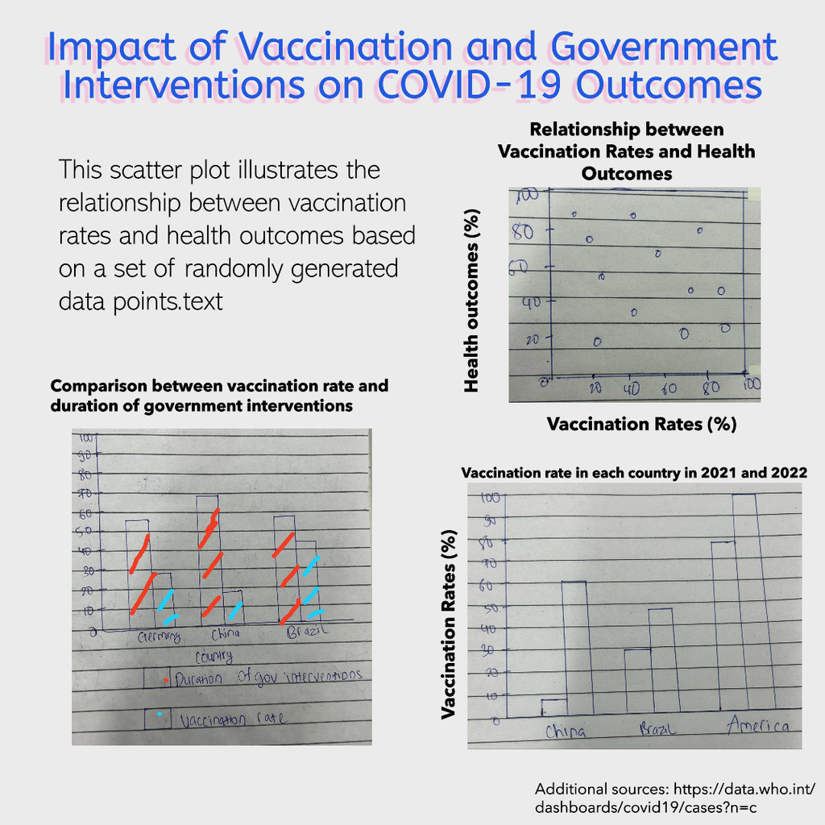

```r
knitr::include_graphics("C:/Users/NGOCNT/Downloads/Design.png")
```

By organizing the dashboard in this way, I aim to create a visually engaging and informative tool that effectively communicates key insights about the pandemic. This layout will enhance public understanding of vaccination and health trends and raise awareness of the importance of ongoing health measures in managing the pandemic.

My dashboard design is tailored for a public audience by ensuring accessibility, understandability, and actionability of the information presented. Accessibility is achieved through a clear layout with a neutral background and contrasting colors, enhancing readability across devices. Understandability is promoted by using simple visualizations, such as bar charts and scatter plots, with concise titles and labels that avoid jargon. A brief narrative summarizing key insights will guide users through the data, making it easier to grasp important trends. Actionability is emphasized by providing links to public health resources and recommendations based on observed data trends, encouraging viewers to engage with the information and make informed health decisions. In summary, the dashboard aims to enhance public understanding of global COVID-19 trends by integrating data from reputable sources on vaccination rates, infection trends, government interventions, and public compliance. Utilizing intuitive visualizations, such as bar charts and scatter plots, along with a clear layout, ensures accessibility and engagement for diverse audiences. The dashboard also emphasizes actionability by providing resources and recommendations to empower informed health decisions. Ultimately, this initiative seeks to educate the public, raise awareness about vaccination, and promote adherence to essential health measures for effective pandemic management. —-